# Data Anaysis of Beetle Richness and Leaf Litter

```r
summary(model_beetle_litter_abundance)
```

```
##
## Call:
## lm(formula = avg_agg_abundance_monthly ~ log(avg_mass_plotmonth),
##     data = beetle_abundance_litter_joined)
##
## Residuals:
##     Min      1Q  Median      3Q     Max
## -42.447 -20.619  -8.135  14.760 111.350
##
## Coefficients:
##                         Estimate Std. Error t value Pr(>|t|)
## (Intercept)               51.986      3.890  13.364   <2e-16 ***
## log(avg_mass_plotmonth)   -4.611      2.287  -2.016   0.0457 *
## ---
## Signif. codes:  0 '***' 0.001 '**' 0.01 '*' 0.05 '.' 0.1 ' ' 1
##
## Residual standard error: 29.54 on 137 degrees of freedom
##   (106 observations deleted due to missingness)
## Multiple R-squared:  0.02882,    Adjusted R-squared:  0.02173
## F-statistic: 4.066 on 1 and 137 DF,  p-value: 0.04572
```

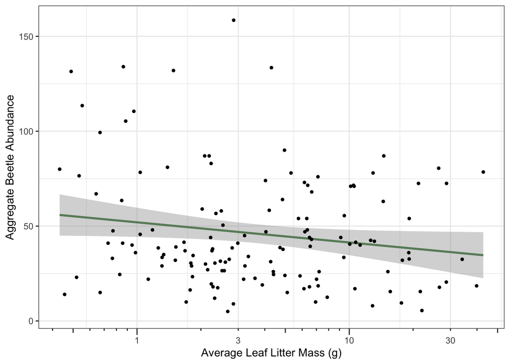

```r
ggplot(beetle_abundance_litter_joined,
       aes(x = avg_mass_plotmonth,
           y = avg_agg_abundance_monthly)) +
  labs(x = "Average Leaf Litter Mass (g)",
       y = "Aggregate Beetle Abundance") +
  geom_smooth(method = "lm",
              col = "darkseagreen4") +
  geom_point(size = 1) +
  scale_x_log10(guide = "axis_logticks") +
  theme_bw()
```

**Figure 2.** Aggregate beetle abundance per month as a function of log of the average leaf litter mass per month (g). Trendline shows global best fit. **(F(1, 137) = 4.066, p = 0.04572)** There is a slight but significant negative relationship between the log of the average leaf litter mass per month and aggregate beetle abundance per month.

Export joined beetle richness and average leaf litter data.

Create aggregate beetle abundance

```r
beetle_abundance_agg <- beetle_abundance_taxonID %>%
  mutate(siteID = substring(plotID, 0, 4)) %>%
  group_by(siteID, collectDate) %>%
  summarize(agg_abundance = sum(count)) %>%
  mutate(monthCollected = month(collectDate),
         yearCollected = year(collectDate)) %>%
  group_by(siteID, yearCollected, monthCollected) %>%
  summarize(avg_agg_abundance_monthly = mean(agg_abundance))
```

Create beetle diversity index

```r
beetle_DI <- beetle_abundance_taxonID %>%
  mutate(siteID = substring(plotID, 0, 4)) %>%
  group_by(siteID, collectDate) %>%
  summarize(simpsonsD = (sum((count/(sum(count)))^2))^(-1), shannonH = -sum((count/sum(count))*log(count/sum(count)))) %>%
    mutate(monthCollected = month(collectDate),
         yearCollected = year(collectDate)) %>%
  group_by(siteID, yearCollected, monthCollected) %>%
  summarize(avg_simpsonsD_monthly = mean(simpsonsD), avg_shannonH = mean(shannonH))
```

Joining created beetle diversity index and aggregate beetle abundance.

```r
total_beetle_litter_joined_table <- beetle_litter_joined_table %>%
  inner_join(beetle_abundance_agg) %>%
  inner_join(beetle_DI)
```

```r
modelsimpsons <- lm(data = total_beetle_litter_joined_table, avg_simpsonsD_monthly ~ log(avg_mass_plotmonth))

summary(modelsimpsons)
```

```
##
## Call:
## lm(formula = avg_simpsonsD_monthly ~ log(avg_mass_plotmonth),
##     data = total_beetle_litter_joined_table)
##
## Residuals:
##     Min      1Q  Median      3Q     Max
## -13.932  -5.250  -1.227   4.266  22.828
##
## Coefficients:
##                         Estimate Std. Error t value Pr(>|t|)
## (Intercept)               17.128      0.956  17.917   <2e-16 ***
## log(avg_mass_plotmonth)   -1.148      0.562  -2.042    0.043 *
## ---
## Signif. codes:  0 '***' 0.001 '**' 0.01 '*' 0.05 '.' 0.1 ' ' 1
##
## Residual standard error: 7.259 on 137 degrees of freedom
## Multiple R-squared:  0.02954,    Adjusted R-squared:  0.02246
## F-statistic: 4.171 on 1 and 137 DF,  p-value: 0.04305
```

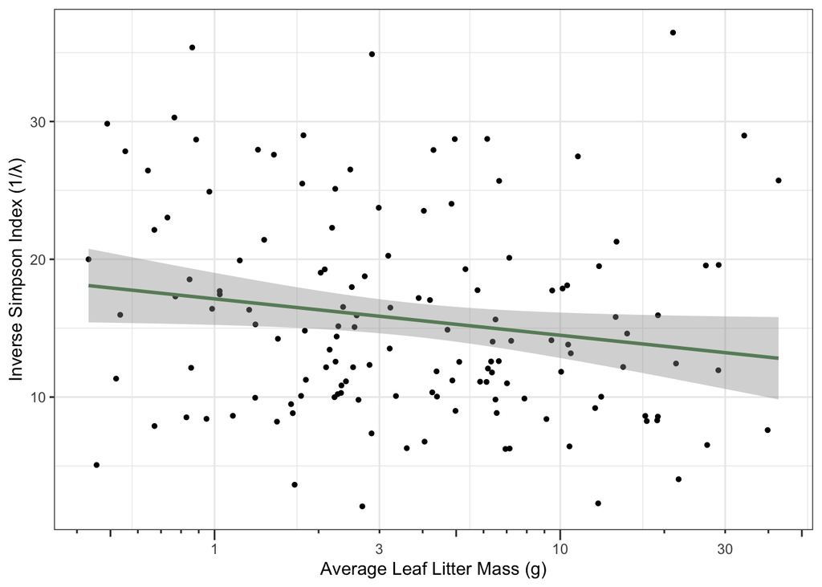

```r
ggplot(total_beetle_litter_joined_table,
       aes(x = avg_mass_plotmonth,
           y = avg_simpsonsD_monthly)) +
  labs(x = "Average Leaf Litter Mass (g)",
       y = "Inverse Simpson Index (1/λ)") +
  geom_point(size = 1)+
  geom_smooth(method = "lm",
              col = "darkseagreen4") +
    scale_x_log10(guide = "axis_logticks") +
  theme_bw()
```

**Figure 3.** Scatterplot visualizing the log of the average leaf litter mass per month (g) v Simpson index of the beetle population. **(F(1, 137) = 4.171, p = 0.04305)**.

```r
beetle_litter_joined_table %>%
   write_csv(here("data", "processed", "beetle_litter_joined_table"))
```